# Rekursif

Python juga menerima rekursi fungsi, yang berarti fungsi yang didefinisikan dapat memanggil dirinya sendiri.

Rekursi adalah konsep matematika dan pemrograman yang umum. Artinya, sebuah fungsi memanggil dirinya sendiri. Hal ini memiliki keuntungan karena memungkinkan kita untuk melakukan perulangan melalui data untuk mencapai suatu hasil.

Pengembang harus sangat berhati-hati dengan rekursi karena sangat mudah untuk tergelincir ke dalam penulisan fungsi yang tidak pernah berakhir, atau fungsi yang menggunakan memori atau daya prosesor secara berlebihan. Namun, jika ditulis dengan benar, rekursi dapat menjadi pendekatan pemrograman yang sangat efisien dan elegan secara matematis.

Dalam contoh ini, tri_recursion() adalah fungsi yang telah kita definisikan untuk memanggil dirinya sendiri ("recurse"). Kita menggunakan variabel k sebagai data, yang nilainya berkurang ( -1 ) setiap kali kita melakukan rekursi. Rekursi berakhir ketika kondisi tidak lebih besar dari 0 (yaitu ketika nilainya 0).

Bagi pengembang pemula, mungkin butuh waktu untuk memahami cara kerjanya secara tepat, cara terbaik untuk mengetahuinya adalah dengan menguji dan memodifikasinya.

```python
#Contoh Rekursi

def tri_recursion(k):
  if(k>0):
    result = k+tri_recursion(k-1)
    print(result)
  else:
    result = 0
  return result

print("\n\nRecursion Example Results")
tri_recursion(6)
```

```
Recursion Example Results
1
3
6
10
15
21
```

```
21
```

### Iteratif

```python
def factorialIteratif(bilangan):
    if bilangan <=1:
        return(1)
    else:
        temp=bilangan
        hasil=1
        while temp>1:
            hasil=hasil*temp
            temp=temp-1
        return(hasil)
```

```python
print(factorialIteratif(4))
```

```
24
```

Suatu permasalahan akan lebih mudah dipecahkan jika permasalahan tersebut berukuran kecil. Misalkan pengurutan data akan lebih mudah dilakukan jika data yang diurutkan hanya terdiri dari dua buah data saja, sehingga pengurutan dapat dilakukan dengan membandingkan dua data tersebut saja.

Rekursif merupakan suatu teknik pemrograman yang memecah permasalahan menjadi permasalahan dengan ukuran yang lebih kecil dan lebih kecil lagi, sehingga permasalahan dengan ukuran kecil tersebut dapat dengan mudah dipecahkan. Teknik ini dapat dilakukan dengan cara memanggil fungsi itu sendiri.

Jika pada contoh sebelumnya, untuk menghitung suatu bilangan dapat dilakukan dengan menggunakan cara iterasi, maka berikut ini adalah penyelesaian perhitungan faktorial dengan cara rekursif.

[figure not shown]

Berikut adalah code untuk perhitungan faktorial dengan cara rekursif

```python
def faktorial(n):
    if n == 0 or n == 1:
        return 1
    else:
        return n * faktorial(n - 1)

angka = 5
hasil = faktorial(angka)
print(f"Faktorial dari {angka} adalah {hasil}")
```

```
Faktorial dari 5 adalah 120
```

Dari fungsi tersebut dapat dilihat bahwa teknik pemrograman rekursif ini melibatkan pemanggilan fungsinya itu sendiri dengan argument atau parameter yang berukuran lebih kecil. Berikut beberapa aturan dalam teknik pemrograman rekursif:

- Fungsi rekursif harus memiliki base case, base case inilah yang berfungsi untuk
- menghentikan pemanggilan terus menerus fungsi rekursif
- fungsi rekursif harus memiliki sintaks yang dapat merubah state dari permasalahan, sehingga
- semakin lama solusi permasalahan menuju base case yang sudah dibuat
- Fungsi rekursif harus memanggil dirinya sendiri

### Implementasi Rekursif

Banyak permasalahan yang dapat diselesaikan dengan teknik pemrograman rekursif ini. Berikut contoh-contoh implementasi rekursif.

#### Triangular Numbers

Terdapat deret bilangan berikut : 1, 3, 6, 10, 15, 21, 28, 36, ... Bagaimanakah pola bilangan tersebut ? Deret bilangan tersebut dikenal dengan nama Triangular Numbers, yang dapat diilustrasikan seperti Gambar 1 berikut.

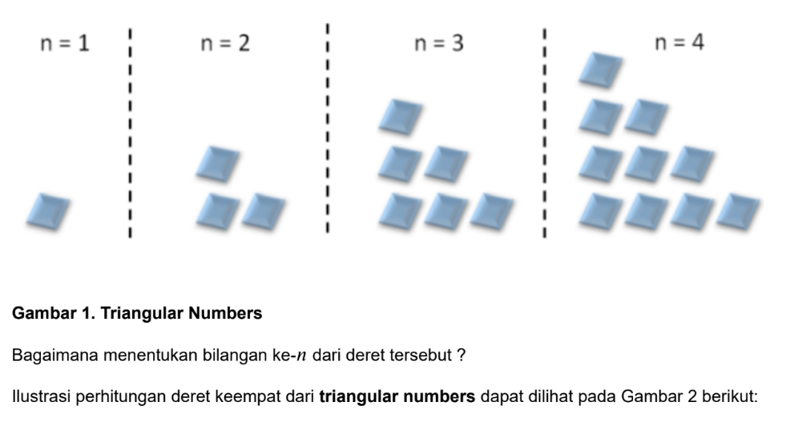

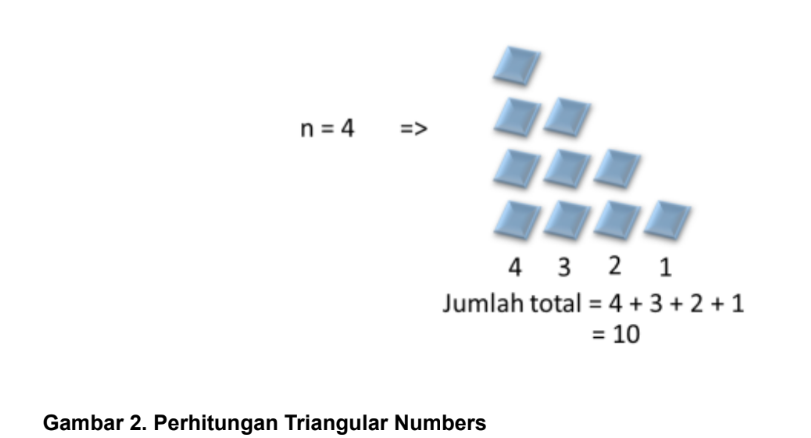

Dapat dilihat pada Gambar tersebut bahwa kolom pertama memiliki 4 kotak, kolom kedua memiliki 3 kotak, kolom ketiga memiliki 2 kotak, dan kolom terakhir memiliki 1 kotak, jumlah kotak total adalah 10, oleh karena itu deret ke-empat dari triangular numbers adalah 10. Berikut fungsi iteratif untuk mencari deret ke-n dari triangular numbers

```python
def triangularNumbers1(n):
    total=0
    temp=n
    while temp>=1:
        total+=temp
        temp-=1
    return(total)

print(triangularNumbers1(2))
```

```
3
```

```python
def triangularNumbers2(n):
    if n==1:
        return(1)
    else:
        return (n + triangularNumbrs2(n-1))

print(triangularNumbers1(8))
```

```
36
```

#### Konversi Bilangan

Bilangan integer dikenal juga sebagai bilangan dengan base 10 (desimal), sehingga memiliki kemungkinan character angka dari 0 s.d 9. Sedangkan base 2 atau yang dikenal nama bilangan biner, hanya memiliki kemungkinan character angka 0 dan 1 saja. Base 8 atau octal, hanya memiliki character 0 s.d 7, sedangkan base 16 atau hexa, memiliki character angka mulai dari 0 s.d 9 dan 'A','B','C','D','E', dan 'F'. Masing-masing bilangan ini dapat dikonversikan menjadi bilangan base lain, akan tetapi yang sering digunakan adalah konversi bilangan desimal ke bilangan base yang lain, atau dari base 2, 8, 16 ke bilangan desimal. Berikut contoh konversi bilangan desimal ke bilangan base 2, 8, atau 16.

Bilangan desimal 8 menjadi bilangan biner '1000'. Untuk merubah bilangan desimal 8 menjadi biner, diperlukan operasi pembagian dan modulo dari bilangan desimal tersebut.

Berikut fungsi rekursif untuk konversi bilangan desimal menjadi bilangan base yang lain.

```python
def konversiDesimal(bilangan,base):
    charBilangan='0123456789ABCDEF'
    if bilangan<base:
        return(charBilangan[bilangan])
    else:
        temp=bilangan//base
        ind=bilangan % base
        print(type(temp),temp,type(ind),ind)
        return(konversiDesimal(temp,base)+charBilangan[ind])

konversiDesimal(5,2)
```

```
<class 'int'> 2 <class 'int'> 1
<class 'int'> 1 <class 'int'> 0
```

```
'101'
```

#### Towers of Hanoi

Berikut code untuk penyelesaian permasalahan towers of hanoi dengan menggunakan teknik rekursif

```python
def towers(n,awal,bantuan,tujuan):
    if n==1:
        print("Piringan - 1 dari-", awal,"ke-",tujuan)
    else:
        towers(n-1,awal,tujuan,bantuan)
        print("Piringan -",n, "dari-",awal,"ke-", tujuan)
        towers(n-1,bantuan,awal,tujuan)

towers(4,'A','B','C')
```

```
Piringan - 1 dari- A ke- B
Piringan - 2 dari- A ke- C
Piringan - 1 dari- B ke- C
Piringan - 3 dari- A ke- B
Piringan - 1 dari- C ke- A
Piringan - 2 dari- C ke- B
Piringan - 1 dari- A ke- B
Piringan - 4 dari- A ke- C
Piringan - 1 dari- B ke- C
Piringan - 2 dari- B ke- A
Piringan - 1 dari- C ke- A
Piringan - 3 dari- B ke- C
Piringan - 1 dari- A ke- B
Piringan - 2 dari- A ke- C
Piringan - 1 dari- B ke- C
```

### Soal - Soal

```python
def pangkat(angka, eksponen):
    # Base case: semua angka pangkat 0 hasilnya 1
    if eksponen == 0:
        return 1
    else:
        return angka * pangkat(angka, eksponen - 1)

print(pangkat(2, 3))  # Output: 8
print(pangkat(5, 0))  # Output: 1
```

```
8
1
```

2. Buatlah sebuah fungsi rekursif bernama jumlah_list(data) yang menerima sebuah list berisi angka dan mengembalikan total hasil penjumlahannya. Dilarang menggunakan fungsi bawaan sum() atau perulangan (for/while).

```python
def jumlah_list(data):
    if len(data) == 0:
        return 0
    else:
        return data[0] + jumlah_list(data[1:])

print(jumlah_list([1, 2, 3, 4, 5]))
print(jumlah_list([10, 20]))
```

```
15
30
```

3. Palindrom adalah kata yang dibaca sama dari depan maupun dari belakang (contoh: "kasur rusak", "malam", "katak"). Buatlah sebuah fungsi rekursif bernama is_palindrom(kata) yang mengembalikan nilai True jika kata tersebut adalah palindrom, dan False jika bukan.

Contoh:

is_palindrom("malam") menghasilkan True.

is_palindrom("python") menghasilkan False.

```python
def is_palindrom(kata):
    if len(kata) <= 1:
        return True
    if kata[0] == kata[-1]:
        return is_palindrom(kata[1:-1])
    else:
        return False
print(is_palindrom("malam"))   # Output: True
print(is_palindrom("python"))  # Output: False
print(is_palindrom("a"))       # Output: True
```

```
True
False
True
```

4. Buatlah sebuah fungsi rekursif hitung_mundur(n) yang mencetak angka dari n hingga 1, dan diakhiri dengan mencetak teks "Selesai!".

```python
def hitung_mundur(n):
    if n == 0:
        print("Selesai!")
        return
    print(n)
    hitung_mundur(n - 1)

# Tes kode
hitung_mundur(3)
```

```
3
2
1
Selesai!
```

5. Buatlah sebuah fungsi rekursif bernama ratakan_list(data) yang menerima sebuah list yang di dalamnya bisa saja terdapat list lain, list di dalam list, dan seterusnya (kedalaman tak terbatas). Fungsi ini harus mengembalikan sebuah list baru 1 dimensi (datar) yang hanya berisi angka-angkanya saja.

```python
def ratakan_list(data):
    hasil_datar = []

    for elemen in data:
        if type(elemen) is list:
            hasil_datar.extend(ratakan_list(elemen))
        else:
            hasil_datar.append(elemen)

    return hasil_datar
print(ratakan_list([1, [2, 3], [[4], 5], 6]))
print(ratakan_list([[[100]], [1, 2], 3]))
```

```
[1, 2, 3, 4, 5, 6]
[100, 1, 2, 3]
```